# Subsídios para a pontuação da produção para credenciamento no PPGE

# Introdução

Temos que incluir em nosso novo regulamento os critérios de pontuação da produção científica e de outras atividades dos orientadores, para fins de credenciamento e recredenciamento.

A CCP planejava realizar uma discussão desses critérios no ano que vem, independente de nossa norma interna. Uma exigência da Pró-Reitoria de PG da USP nos obrigou a adiantar esta discussão, conforme informado na mensagem que enviamos por email os orientadores e estudantes.

Este documento apresenta a proposta da CCP para discussão na Plenária do Programa. Também selecionamos informações que fundamentam a proposta.

## Exigências da PRPG

Atualmente definimos a pontuação da produção para credenciamento em norma interna que fica em nosso site, para nos dar mais flexibilidade. O Pró-reitor de Pós-Graduação impôs a todos os Programas que a pontuação esteja nas normas. Além disto, exigiu que a nova pontuação exija:

- Produção média de um artigo por ano
- Publicação de rtigos em periódicos nos estratos superiores de qualidade segundo a CAPES
- Produção com discentes ou egressos

O novo Regimento da Pós-Graduação da USP nos obriga a enviar novo regulamento, para apreciação pela PRPG. A aprovação desse novo regulamento depende de atendermos as imposições do Pró-Reitor. Esgotamos nossas possibilidades de negociação a respeito. O novo regulamento deve ser enviado ao Conselho de PG da USP até março de 2020. Isto significa que temos que encaminhar nossa proposta à CPG em dezembro de 2019.

## Mudanças na avaliação CAPES

Em agosto de 2019 a CAPES apresentou mudanças em sua avaliação aos coordenadores. Houve mudanças no QUALIS e na avaliação da produção do programa. As mudanças importantes para a pontuação da produção são:

- Cada periódico terá apenas um estrato QUALIS. Atualmente cada área de conhecimento faz sua classificação, e assim muito periódicos são classificados em estratos diferentes dependendo da área.
- O estrato QUALIS único de cada periódico será definido pelo *quantil de fator de impacto* (**qIF**), que é a proporção de periódicos de uma área que tem fator de impacto (IF) menor do que o periódico avaliado[^1].
  - Serão usadas as áreas de conhecimento e valores de qIF das bases https://www.scopus.com/ e https://jcr.clarivate.com.
  - Se o periódico tiver mais de um valor de qIF registrado nas bases será usado o maior valor [^2].
- Os indicadores de produçao dos docentes e do programa serão somas dos qIF por artigos publicado.
- Para indicadores de formação, os qIF de produções sem participação de discentes ou egressos é dividida pela metade, e então somados aos qIF das produções com participação.

### Nova tabela QUALIS

- O novo QUALIS terá quatro estratos *A* e quatro *B*, separados por intervalos regulares de 12,5.
- Os estratos *A* passam a indicar periódicos com qIF acima de 50% (ou seja, acima da mediana de IF)

| Estrato | qIF |
| --- | --- |
| A1 | > 87,5 |
| A2 | 87,5 - 75 |
| A3 | 75 - 62,5 |
| A4 | 62,5 - 50 |
| B1 | 50 - 37,5 |
| B2 | 37,5 - 25 |
| B3 | 25 - 12,5 |
| B4 | < 12,5 |

## Propostas adicionais da CCP

- Aumentar a ênfase em outras contribuições dos orientadores ao programa, além de sua produção;
- Aperfeiçoar a pontuação para estas contribuições;
- Na avaliação de produção contemplar produtos e ações para divulgação e aplicação do conhecimento científico para benefício da sociedade.

## Nosso sistema atual de credenciamento

- Adotamos pontuação de produção e outras atividades
- É preciso ter pelo menos 210 pontos de produção.
- A pontuação dos artigos é A1 = 100 pontos, A2 = 85 , B1 = 70, B2 = 55 , B3 = 40 , B4 = 25 , B5 = 10.
- Capítulos de livros podem acumular até 140 pontos
- Recredenciamento a cada 3 anos
- Para recredenciamento é preciso, além dos 210 pontos de produção, 4 créditos em atividades de contribuição ao funcionamento do programa, cujo cálculo está detalhado em nosso site (http://www.posecologia.ib.usp.br/2017-07-14-22-11-28/credenciamento.html).

# Nossa proposta

Nesta seção apresentamos a proposta de pontuação de artigos e avaliamos sua equivalência com a pontuação anterior. Os demais critérios para credenciamento estão na minuta enviada a todos os orientadores do Programa.

## Proposta de pontuação

- **A soma de qIF de artigos publicados nos últimos 36 meses deve ser no mínimo de 160**.
- Outras modalidades de produção são pontuadas buscando uma equivalência em impacto ou horas de trabalho (ver minuta).
- Produto com discentes ou egressos ganham bônus: pontuação multiplicada por 1,25.

Com esta proposta buscamos:

- Atender às demandas da PRPG da seguinte forma:
  - inclusão de um sistema de pontuação da produção acadêmica nas normas;
  - propor uma alternativa mais flexível à exigência de publicação de um artigo por ano. A soma de 160 pontos de qIF equivale a 3 artigos de IF superior à mediana. Mas contempla diferentes perfis de produção (*e.g*, mais artigos em periódicos de menor IF ou menor número em periódicos de maior IF);
  - valorizar produção com discente ou egresso.
- Acompanhar as novas metodologias de avaliação de produção da CAPES;
- Deixar margem para os outros critérios sugeridos pela CCP (outras contribuições, outros tipos de produção).

## Equivalência com o sistema anterior

### Qualis antigo e novo

Embora haja alguma associação entre as duas classificações QUALIS, há também muitos títulos que mudaram de estratos. Há muitas razões para isto, inclusive a criação dos estratos A3 e A4 e o rebaixamento de periódicos de alto impacto mas considerados de pouca aderência na classificação antiga.

Número de periódicos área de Biodiversidade por combinação de seu estrato QUALIS da avaliação anterior (colunas) e da avaliação atual (linhas). Dados: todos os periódicos da área que constam no QUALIS antigo e no SCOPUS de 2018.

|  | A1 | A2 | B1 | B2 | B3 | B4 | B5 | C |
| --- | --- | --- | --- | --- | --- | --- | --- | --- |
| A1 | 149 | 104 | 124 | 37 | 9 | 3 | 1 | 20 |
| A2 | 29 | 101 | 131 | 73 | 11 | 2 | 2 | 15 |
| A3 | 2 | 34 | 143 | 120 | 30 | 2 | 4 | 17 |
| A4 | 2 | 8 | 56 | 119 | 53 | 4 | 9 | 10 |
| B1 | 0 | 3 | 28 | 84 | 71 | 18 | 5 | 9 |
| B2 | 0 | 0 | 4 | 47 | 52 | 26 | 13 | 6 |
| B3 | 0 | 1 | 0 | 20 | 22 | 28 | 22 | 23 |
| B4 | 0 | 0 | 0 | 3 | 8 | 14 | 13 | 6 |

### Pontuação antiga e nova

Para avaliar a relação entre a pontuação antiga e nova simulamos conjuntos de artigos e calculamos a sua pontuação pelos dois sistemas. Para isto sorteamos com reposição 10^{5} amostras de títulos da lista. As amostras tinham entre um e seis títulos, com igual probabilidade. Estas combinações geraram pontuações pelo sistema antigo variando de 0 a 540.

As duas pontuações das combinações simuladas são proporcionais, embora com bastante variação. Mais importante, há pouquíssimas combinações que teria pontuação mínima para credenciamento no sistema antigo (210 pontos) mas não teriam no sistema novo (160 pontos).

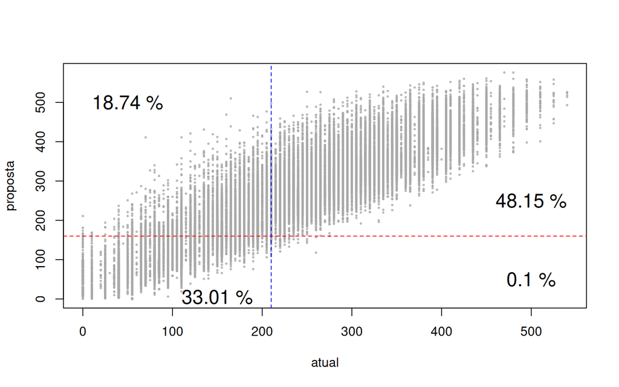

Pontuação proposta em função da atual para produções simuladas de uma a seis artigos, sorteadas da lista de periódicos da área de Biodiversidade. A linha azul marca a pontuação mínima para credenciamento no sistema atual. A linha vermelha marca a pontuação mínima no novo sistema proposto.

Para verificar este resultado, simulamos amostras em que novos títulos eram acrescentados até que a pontuação pelo sisetma antigo permitisse credenciamento. Estas simulações aproximam combinações de artigos com o mínimo de pontos para o credenciamento, pelo sistema antigo. Apenas 0.44% das combinações tiveram pontuação menor que 160 pelo sistema proposto.

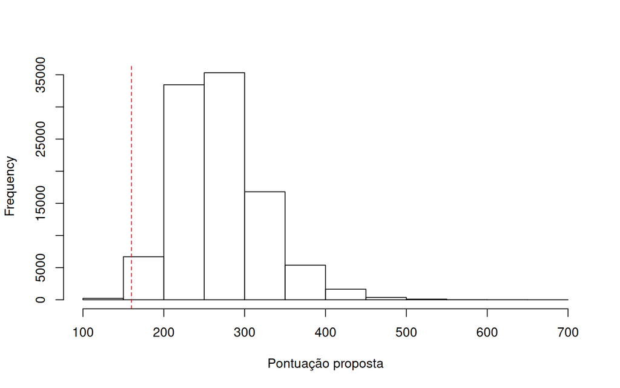

Distribuição de pontos pelo sistema proposto de combinações de publicações com pontuação mínima para credenciamento pelo sistema antigo

Em resumo, o novo sistema de pontuação da produção de artigos tem chance virtualmente nula de impedir credenciamento de alguém que tenha pontuação para credenciamento pelo sistema antigo.

# Arquivos de dados

Arquivos usados nas análise acima. Podem ser importados para qualquer planilha eletrônica. Sugerimos que os(as) orientadores(as) verifiquem antes da plenária os qIFs dos periódicos onde têm publicado seus artigos. Esses dados estão na planilha da SCOPUS. Isto vai ajudar a avaliarmos a pontuação proposta.

- QUALIS 2016: classificação QUALIS usada na avaliação quadrienal 2013-2016 da área de Biodiversidade. Baixado do sistema [Sucupira](https://sucupira.capes.gov.br)
- Scopus 2018: qIF máximo dos periódicos que constam na base SCOPUS 2018. Baixado da SCOPUS.
- QUALIS 2016 com qIF 2018: títulos do QUALIS 2013-2016 da Biodiversidade que constam na base Scopus 2018, com seus qIFs máximos.
[^1]: Por exemplo: um periódico com quantil de IF = 95 tem fator de impacto (IF) maior do que 95% dos periódicos da área.
[^2]: Em geral os periódicos têm mais de um quantil de IF, porque estão classificados em mais de uma base ou em mais de uma área de conhecimento na mesma base. O uso do quantil máximo acomoda diferenças dos impactos médios entre áreas, sendo a opção de menor prejuízo para área que têm IFs médios menores.
[^3]: O que não é mesmo que o número de títulos porque as versões impressas e eletrônicas do periódicos têm ISSN separados.

Coordenação do PPGE

2019-11-12